# Untitled

Nida

5/28/2017

# Reproducible Research: Peer Assessment 1

## Set the working directory

```r
setwd("~/Desktop/coursera")
```

## Load the data

```r
activity <- read.csv("activity.csv", header = TRUE, sep = ",")
head(activity)
```

```
##   steps       date interval
## 1    NA 2012-10-01        0
## 2    NA 2012-10-01        5
## 3    NA 2012-10-01       10
## 4    NA 2012-10-01       15
## 5    NA 2012-10-01       20
## 6    NA 2012-10-01       25
```

## View the data

```r
str(activity)
```

```
## 'data.frame':    17568 obs. of  3 variables:
##  $ steps   : int  NA NA NA NA NA NA NA NA NA NA ...
##  $ date    : Factor w/ 61 levels "2012-10-01","2012-10-02",..: 1 1 1 1 1 1 1 1 1 1 ...
##  $ interval: int  0 5 10 15 20 25 30 35 40 45 ...
```

```r
summary(activity)
```

```
##      steps                date          interval
##  Min.   :  0.00   2012-10-01:  288   Min.   :   0.0
##  1st Qu.:  0.00   2012-10-02:  288   1st Qu.: 588.8
##  Median :  0.00   2012-10-03:  288   Median :1177.5
##  Mean   : 37.38   2012-10-04:  288   Mean   :1177.5
##  3rd Qu.: 12.00   2012-10-05:  288   3rd Qu.:1766.2
##  Max.   :806.00   2012-10-06:  288   Max.   :2355.0
##  NA's   :2304     (Other)   :15840
```

## Convert date class to ‘Date’

```r
activity$date <- as.Date(as.character(activity$date))
```

## Mean total number of steps taken per day

### 1 Calculate total number of steps per day

```r
stepsPerDay <- aggregate(steps ~ date, activity, sum, na.rm=TRUE)
head(stepsPerDay)
```

```
##         date steps
## 1 2012-10-02   126
## 2 2012-10-03 11352
## 3 2012-10-04 12116
## 4 2012-10-05 13294
## 5 2012-10-06 15420
## 6 2012-10-07 11015
```

### 2 Make a histogram of the total number of steps taken each day

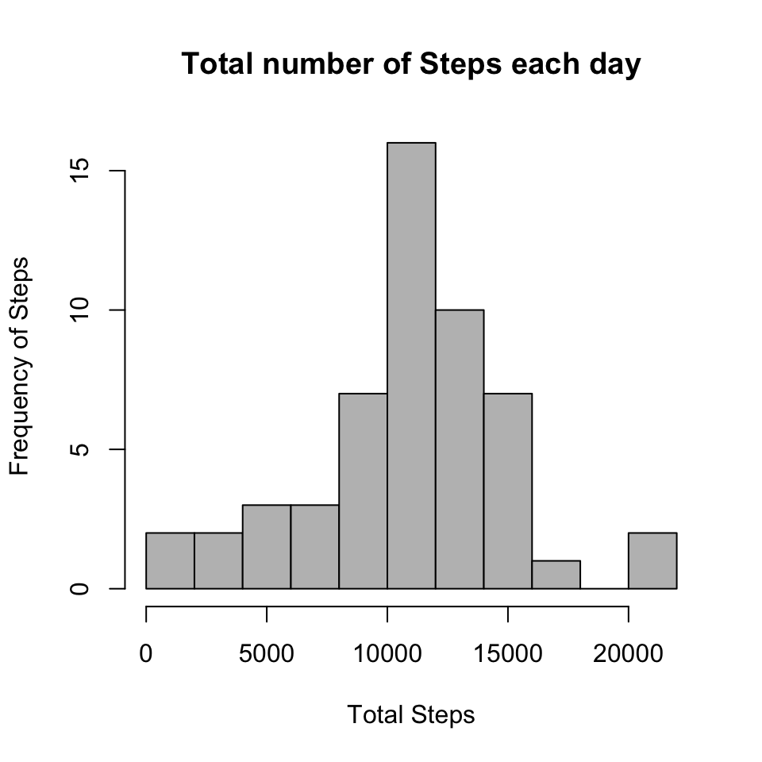

```r
hist(stepsPerDay$steps, border="black", col="grey", breaks=10, xlab="Total Steps", ylab="Frequency of Steps", main = "Total number of Steps each day")
```

###3 Calculate and report the mean and median of the total number of steps taken per day

```r
mean(stepsPerDay$steps)
```

```
## [1] 10766.19
```

```r
median(stepsPerDay$steps)
```

```
## [1] 10765
```

## What is the average daily activity pattern

### 1 Make a time series plot (i.e. 𝚝𝚢𝚙𝚎 = “𝚕”) of the 5-minute interval (x-axis) and the average number of steps taken, averaged across all days (y-axis)

#### Calculate the average number of steps taken

```r
averageSteps <- aggregate(steps ~ interval, activity, mean, na.rm=TRUE)
head(averageSteps)
```

```
##   interval     steps
## 1        0 1.7169811
## 2        5 0.3396226
## 3       10 0.1320755
## 4       15 0.1509434
## 5       20 0.0754717
## 6       25 2.0943396
```

#### Compute the time series plot

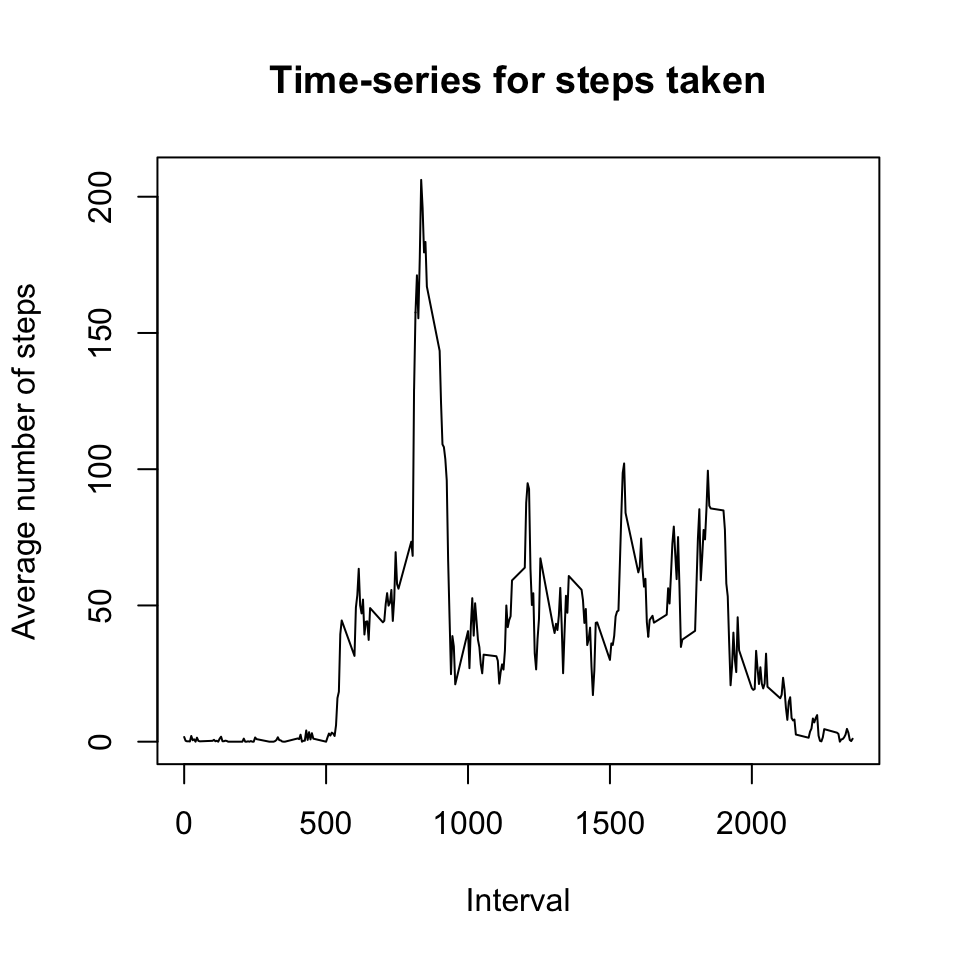

```r
plot(averageSteps$interval, averageSteps$steps,  type = "l", col="black", xlab ="Interval", ylab="Average number of steps", main = "Time-series for steps taken")
```

###2 Which 5-minute interval, on average across all the days in the dataset, contains the maximum number of steps

```r
averageSteps[which.max(averageSteps$steps),]$interval
```

```
## [1] 835
```

## Imputing missing values

### 1 Calculate and report the total number of missing values in the dataset (i.e. the total number of rows with 𝙽𝙰s)

```r
length(which(is.na(activity$steps)))
```

```
## [1] 2304
```

### 2 Devise a strategy for filling in all of the missing values in the dataset

```r
options(digits = 2)
activity$newSteps<- ifelse(is.na(activity$steps), mean(activity$steps, na.rm = TRUE), activity$steps)
head(activity, 10)
```

```
##    steps       date interval newSteps
## 1     NA 2012-10-01        0       37
## 2     NA 2012-10-01        5       37
## 3     NA 2012-10-01       10       37
## 4     NA 2012-10-01       15       37
## 5     NA 2012-10-01       20       37
## 6     NA 2012-10-01       25       37
## 7     NA 2012-10-01       30       37
## 8     NA 2012-10-01       35       37
## 9     NA 2012-10-01       40       37
## 10    NA 2012-10-01       45       37
```

### 3 Create a new dataset that is equal to the original dataset but with the missing data filled in

```r
newActivity <- activity[,-1]
head(newActivity)
```

```
##         date interval newSteps
## 1 2012-10-01        0       37
## 2 2012-10-01        5       37
## 3 2012-10-01       10       37
## 4 2012-10-01       15       37
## 5 2012-10-01       20       37
## 6 2012-10-01       25       37
```

### 4 Make a histogram of the total number of steps taken each day and Calculate and report the mean and median total number of steps taken per day.

#### Calculate total number of steps taken each day

```r
newStepsPerDay <- aggregate(newSteps ~ date, newActivity, sum, na.rm=TRUE)
newStepsPerDay$newSteps<- as.numeric(newStepsPerDay$newSteps)
head(newStepsPerDay)
```

```
##         date newSteps
## 1 2012-10-01    10766
## 2 2012-10-02      126
## 3 2012-10-03    11352
## 4 2012-10-04    12116
## 5 2012-10-05    13294
## 6 2012-10-06    15420
```

#### Make a histogram of the total number of steps taken each day

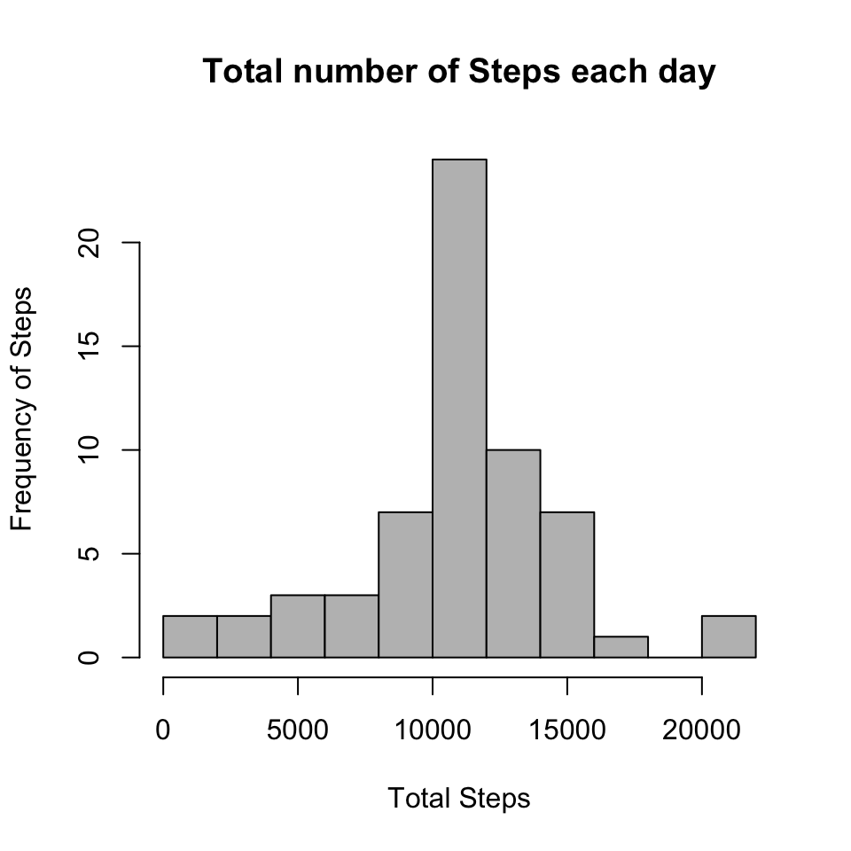

```r
hist(newStepsPerDay$newSteps, border="black", col="grey", breaks=10, xlab="Total Steps", ylab="Frequency of Steps", main = "Total number of Steps each day")
```

#### Calculate and report the mean and median total number of steps taken per day

```r
mean(newStepsPerDay$newSteps)
```

```
## [1] 10766
```

```r
median(newStepsPerDay$newSteps)
```

```
## [1] 10766
```

. There is no significant impact of imputing missing data on the estimates of the total daily number of steps

## Are there differences in activity patterns between weekdays and weekends?

### 1 Create a new factor variable in the dataset with two levels – “weekday” and “weekend” indicating whether a given date is a weekday or weekend day.

```r
newActivity$day <-  ifelse(as.POSIXlt(newActivity$date)$wday %in% c(0,6), 'weekend', 'weekday')
newActivity$day <- as.factor(newActivity$day)
str(newActivity)
```

```
## 'data.frame':    17568 obs. of  4 variables:
##  $ date    : Date, format: "2012-10-01" "2012-10-01" ...
##  $ interval: int  0 5 10 15 20 25 30 35 40 45 ...
##  $ newSteps: num  37.4 37.4 37.4 37.4 37.4 ...
##  $ day     : Factor w/ 2 levels "weekday","weekend": 1 1 1 1 1 1 1 1 1 1 ...
```

### 2 Make a panel plot containing a time series plot (i.e. 𝚝𝚢𝚙𝚎 = “𝚕”) of the 5-minute interval (x-axis) and the average number of steps taken, averaged across all weekday days or weekend days (y-axis).

#### Load the package

```r
library(ggplot2)
```

#### Generate the time series plot using ‘ggplot’ function

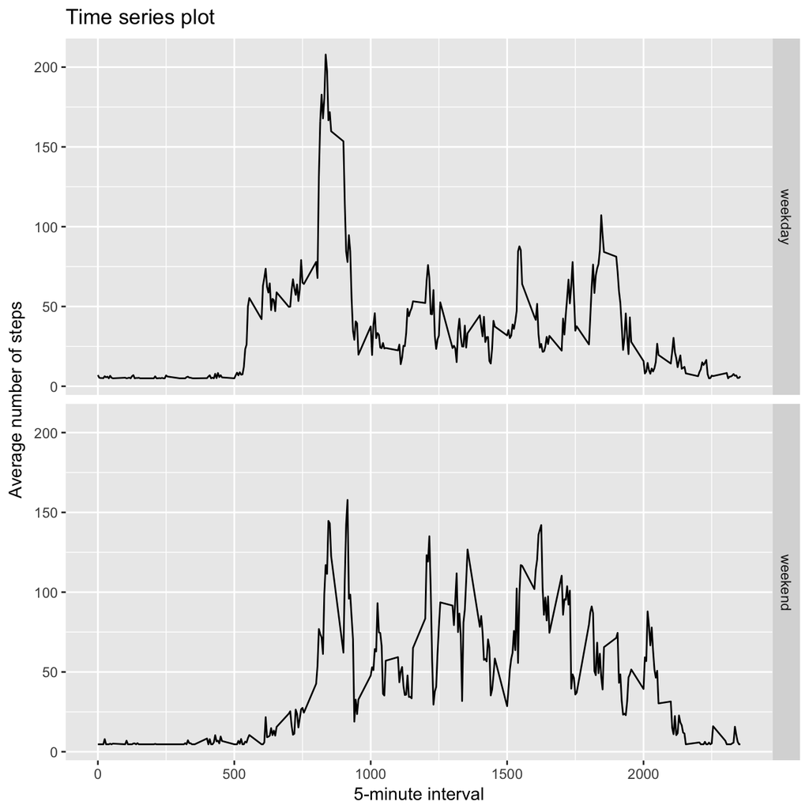

```r
averageNewSteps <- aggregate(newSteps ~ interval + day, newActivity, mean)
p <- ggplot(averageNewSteps, aes(interval, newSteps))
   p + geom_line() +
    facet_grid(day ~ .) +
    xlab("5-minute interval") +
    ylab("Average number of steps")+
    ggtitle("Time series plot")
```